# STAT1378 Assignment

**Exercise 1** [20 points] As output of this exercise, you are required to submit an R script (`A3_ex1.R`) able to complete the operations listed below.

1. Read the file `A3_Ex1.csv` in a data frame or tibble `X`

```r
library(tidyverse)
X <- read_csv("A3_Ex1.csv")
```

2. Show the structure of `X` (`str(X)`)

```r
str(X)
```

```
## spec_tbl_df [1,000 × 4] (S3: spec_tbl_df/tbl_df/tbl/data.frame)
##  $ day        : num [1:1000] 1 2 31 18 14 31 13 10 8 14 ...
##  $ month      : chr [1:1000] "Jan" "Mar" "Jan" "Jul" ...
##  $ weather    : chr [1:1000] "sunny" "sunny" "sunny" "cloudy" ...
##  $ expenditure: num [1:1000] 83.8 389.8 147.5 328.9 148.3 ...
##  - attr(*, "spec")=
##   .. cols(
##   ..   day = col_double(),
##   ..   month = col_character(),
##   ..   weather = col_character(),
##   ..   expenditure = col_double()
##   .. )
```

3. Compute and show the total sum of the expenditures

```r
sum(X$expenditure)
```

```
## [1] 201932.5
```

4. Compute and show the sum of the expenditures in March

```r
X %>% filter(month == "Mar") %>% select(expenditure) %>% sum()
```

```
## [1] 49481.11
```

5. Compute and show the sum of the expenditures in March when the weather is cloudy

```r
X %>% filter(month == "Mar", weather == "cloudy") %>%
  select(expenditure) %>% sum()
```

```
## [1] 16874.8
```

6. Find and show the month with the highest expenditure

```r
X %>% group_by(month) %>% summarise(sum = sum(expenditure)) %>%
  filter(sum == max(sum))
```

```
## # A tibble: 1 x 2
##   month    sum
##   <chr>  <dbl>
## 1 Jul   53601.
```

**Exercise 2 [20 points]** As output of this exercise, you are required to submit an R script (`A3_ex2.R`) able to complete the operations listed below. Please note: as there is random number generation involved, it is of paramount importance that we are able to generate the same random numbers. In order to achieve this, at the beginning of the script, you need to run a command to set the random seed.

0. Run `set.seed(2048)`

```r
set.seed(2048)
```

1. Create a list `X` with `N = 100` slots, and in each slot create a list of two elements:
- name, along the lines of `“n1”`, `“n2”`, `“n3”`, …, `“n100”`
- vect, a numeric vector of 5 elements sampled from a normal distribution with $\mu = 23$ and $\sigma = 5$.

```r
X <- map(1:100, ~ list(name = glue::glue("n{.x}"),
                  vect = rnorm(5, mean = 23, sd = 5)))
```

2. Show the structure of `X` (`str(X)`).

```r
str(X)
```

```
## List of 100
##  $ :List of 2
##   ..$ name: 'glue' chr "n1"
##   ..$ vect: num [1:5] 18.8 21.2 21.2 24.4 25.6
##  $ :List of 2
##   ..$ name: 'glue' chr "n2"
##   ..$ vect: num [1:5] 20.9 19.1 18.7 17.9 17.8
##  $ :List of 2
##   ..$ name: 'glue' chr "n3"
##   ..$ vect: num [1:5] 31.1 17.4 23 24.4 22.1
##  $ :List of 2
##   ..$ name: 'glue' chr "n4"
##   ..$ vect: num [1:5] 32.1 18.6 31.1 19 18.8
##  $ :List of 2
##   ..$ name: 'glue' chr "n5"
##   ..$ vect: num [1:5] 20.5 23.8 21.9 21.1 19.5
##  $ :List of 2
##   ..$ name: 'glue' chr "n6"
##   ..$ vect: num [1:5] 22.6 34.9 24.7 24.7 18.9
##  $ :List of 2
##   ..$ name: 'glue' chr "n7"
##   ..$ vect: num [1:5] 27.5 17.5 19.4 24.5 20.3
##  $ :List of 2
##   ..$ name: 'glue' chr "n8"
##   ..$ vect: num [1:5] 30 24.7 30.6 21.9 26.6
##  $ :List of 2
##   ..$ name: 'glue' chr "n9"
##   ..$ vect: num [1:5] 28.4 23.1 20.8 25.8 23.7
##  $ :List of 2
##   ..$ name: 'glue' chr "n10"
##   ..$ vect: num [1:5] 22.7 25.4 25.1 20.5 31.6
##  $ :List of 2
##   ..$ name: 'glue' chr "n11"
##   ..$ vect: num [1:5] 25 23.7 27.5 17.5 23.5
##  $ :List of 2
##   ..$ name: 'glue' chr "n12"
##   ..$ vect: num [1:5] 26.1 30.9 21.7 22 26.2
##  $ :List of 2
##   ..$ name: 'glue' chr "n13"
##   ..$ vect: num [1:5] 26.3 23.4 28 21.3 20
```

[output cut: 244 more lines]

```
##   ..$ name: 'glue' chr "n95"
##   ..$ vect: num [1:5] 32.1 22.5 14.2 29.7 26.7
##  $ :List of 2
##   ..$ name: 'glue' chr "n96"
##   ..$ vect: num [1:5] 16.2 26.2 24.3 25.1 22.1
##  $ :List of 2
##   ..$ name: 'glue' chr "n97"
##   ..$ vect: num [1:5] 25.2 14.6 23.9 22.1 33.7
##  $ :List of 2
##   ..$ name: 'glue' chr "n98"
##   ..$ vect: num [1:5] 18.5 22.7 21.4 26.8 22.8
##  $ :List of 2
##   ..$ name: 'glue' chr "n99"
##   ..$ vect: num [1:5] 21 14 17 24.6 19.8
##   [list output truncated]
```

3. Compute the sum of the values of `vect` in each slot and show the output. The output must be a vector of 100 values.

```r
map_dbl(1:100, ~ sum(X[[.x]]$vect))
```

```
##   [1] 111.24138  94.24937 117.95952 119.51781 106.83666 125.86594 109.12188
##   [8] 133.68112 121.85436 125.29786 117.29220 126.97630 119.06546 126.80154
##  [15]  95.83727 126.53685 119.98466 110.16704  79.22852 109.56964 127.10409
##  [22] 123.95137 112.37518 132.38541 119.50909 115.95040 112.85811 125.24035
##  [29] 101.01510 107.15376 116.44793 125.00817 103.30847 126.01719 114.13239
##  [36] 127.98386 125.36204 100.70031 109.39963 107.77405 123.60870 112.73161
##  [43] 108.93899 109.43635 131.00015 109.19284 110.45159 116.80499 146.09333
##  [50]  93.13754 111.62889 113.53973 103.37926 107.34505 109.97344 126.14851
##  [57] 108.85447 111.83879 108.29476 100.80080 126.09491  89.21139 117.31247
##  [64] 100.89352 100.72460 126.06160 129.63976 107.41147 112.32011 117.04701
##  [71]  97.97999 109.93449 124.62090 112.31342 104.12720 121.54085 115.23980
##  [78] 110.73527  85.43743 127.00966 104.79095 111.80141 106.37047 108.40647
##  [85] 109.64268 109.85118 121.40143 121.19381 125.12569 102.48751 115.42782
##  [92] 113.68544 111.86010  98.11318 125.20051 113.98518 119.54658 112.13463
##  [99]  96.39274 119.44078
```

4. Create a matrix `M` (not a data frame) of size 100× 5 using the 100 `vect` objects in the slots of `X`.

```r
Y <- vector("list", 100)
for (i in 1:100) {
  Y[[i]] <- X[[i]]$vect
}
M <- matrix(unlist(Y), byrow = TRUE, ncol = 5)
```

5. Use a `for` loop to compute the sums by columns of `M` and show the result.

```r
sums_M <- double(5)
for (i in 1:5) {
  sums_M[i] <- M[, i] %>% sum()
}
sums_M
```

```
## [1] 2260.353 2246.963 2291.927 2332.569 2244.665
```

**Exercise 3 [60 points]** In this exercise you are required to read the files `A3_Ex3_signif.csv` and `A3_Ex3_not_signif.csv` and write the code to test the hypothesis

$H_0: \beta = 0$ against $H_1 : \beta \neq 0$,

where $\beta$ is the slope parameter of a simple linear model

$Y_i = \alpha + \beta X_i + \epsilon_i$,

with $\epsilon_i ∼ N(0, \sigma)$ and $i \in 1, . . . , N$. $N$ is the sample size.

The structure of the test is:

1. State the Null Hypothesis and the Alternative Hypothesis
2. Check the assumptions, plotting (a) $y$ vs $x$, (b) the scatter plot of the regression residuals $\epsilon_i$ vs the fitted values $\hat{y}$ and (c) the histogram of the regression residuals $\epsilon_i$. Only 3 graphs are required for this point, there is no need to comment.
3. Perform the linear regression and report the values of the estimated slope $\hat{\beta}$, the 95% CIs for $\beta$, the value of $t$, the degree of freedom $df$, and the p-value.
4. Write the “decision” of the test, either rejection or not rejection of the Null Hypothesis, at 5% significance level.
5. Write a conclusion to the test, i.e., one or two sentences in English in which you explain the results and describe the relationship or lack of relationship between $X$ and $Y$.

The linear regression model must be run with the R command `lm()`. Some of the information needed to complete the exercise can be directly extracted from the object in output (after its examination with the command `str()` or use the `broom` package), while other parts may need to be computed.

As output, you need to produce a single file `A3_ex3.R` containing the code to generate the required results.

You can solve this exercise at different levels.

- Pass [24 points]: writing a sequence of commands that work only on the given data sets. In this case, you need to run the test twice, once per data set, and each time you need to write the conclusion that is correct for the specific case you are considering.
- Credit [10 points]: As at the pass level, but writing the conclusions programmatically, i.e., using a function that takes in input the values of $\hat{\beta}$ and the p-value and is able to output the correct message.
- Distinction [10 points]: fully solving the problem with the following functions, called sequentially from a script:
  - `hypothesis(file_name)`
  - `assumptions(file_name)` (Please note, you will need to run the linear regression model to get the residuals)
  - `fit1 <- fit(file_name)`
  - `decision(fit1)`
  - `conclusion(fit1)`
- High Distinction [16 ponts]: As at the distinction level, but the function `fit(file_name)` returns an object of class `mylm`. Methods named `decision.mylm(fit)` and `conclusion.mylm(fit)` can be called with `decision(fit)` and `conclusion(fit)`. The full test can be called with a function `mytest(file_name)`, which calls everything needed and outputs a nicely formatted report (i.e. a sequence of `cat` and `plot` (or `ggplot`) commands from all the functions called sequentially).

```r
signif <- read_csv("A3_Ex3_signif.csv")
not_signif <- read_csv("A3_Ex3_not_signif.csv")
library(glue)
```

```r
library(patchwork)


input <- function(df) {
  functions <- function() {
    lm1 <- lm(Y ~ X, df)


    hypothesis <- function() {
      glue("testing H_0: beta = 0 against H_1: beta != 0")
    }


    assumptions <- function() {
      (ggplot(df, aes(X, Y)) + geom_point(size = 0.5) +
         geom_smooth(method = lm, formula = y ~ x) + ggtitle("X vs. Y") +
      ggplot(data.frame(x = lm1$fitted.values, y = lm1$residuals),
             aes(x, y)) + geom_point(size = 0.5) +
        geom_smooth(method = lm, se = FALSE, formula = y ~ x) +
        labs(title = "Regression residuals vs. fitted values",
             x = "fitted values", y = "residuals")) /
      ggplot(data.frame(x = lm1$residuals), aes(x)) +
        geom_histogram(bins = 30) +
        labs(title = "Histogram of regression residuals",
             x = "residual bins")
    }


    fit <- function() {
      x <- summary(lm1)$coefficients[2, 4]
      cat(glue("beta_hat = {summary(lm1)$coefficients[2, 1]}"),
          glue("95% confindence interval for beta: [{confint(lm1)[2, 1]}, {confint(lm1)[2, 2]}]"),
          glue("t value: {summary(lm1)$coefficients[2, 3]}"),
          glue("degrees of freedom: {summary(lm1)$df[2]}"),
          glue("p-value: {summary(lm1)$coefficients[2, 4]}"), sep = "\n")
      class(x) <- "mylm"
      invisible(x)
    }


    decision.mylm <- function(fit) {
      glue(c("H_0 is retained at a 5% significance level", "H_0 is rejected at a 5% significance level")[as.numeric(fit < 0.05) + 1])
    }
    decision.default <- function(fit) {
      stop("Class of argument is not 'mylm'. Have you tried turning it off and on again?")
    }
    decision <- function(fit) {
      UseMethod("decision")
    }


    conclusion.mylm <- function(fit) {
      glue(c("Conclusion: since the p-value is greater than 0.05, at a 5% significance level, the null hypothesis is retained since there is insufficient evidence to conclude that there is a linear relationship between variables X and Y", "Conclusion: since the p-value is less than 0.05, at a 5% significance level, there is sufficient evidence to reject the null hypothesis in favour of the alternative and conclude that there is a linear relationship between variables X and Y")[as.numeric(fit < 0.05) + 1])
    }
    conclusion.default <- function(fit) {
      stop("Class of argument is not 'mylm'. Maybe try using more brain cells.")
    }
    conclusion <- function(fit) {
      UseMethod("conclusion")
    }

    mytest <- function() {
      cat(hypothesis(), "\n \n", sep = "")
      print(invisible(assumptions()))
      f <- fit()
      cat("\n", decision(f), "\n \n",  conclusion(f), sep = "")
    }

    list(hypothesis = hypothesis, assumptions = assumptions, fit = fit,
         decision = decision, conclusion = conclusion, mytest = mytest,
         decision.mylm = decision.mylm,
         decision.default = decision.default,
         conclusion.mylm = conclusion.mylm,
         conclusion.default = conclusion.default)
    }

  functions <- functions()
  for (i in names(functions)) {
    assign(i, functions[[i]], envir = globalenv())
  }
}


input(signif)
hypothesis()
```

```
## testing H_0: beta = 0 against H_1: beta != 0
```

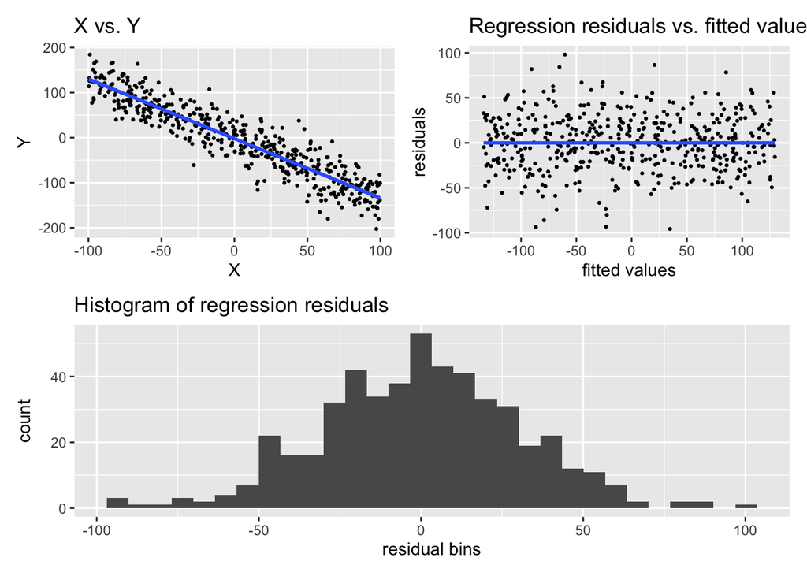

```r
assumptions()
```

```r
f <- fit()
```

```
## beta_hat = -1.32011907668038
## 95% confindence interval for beta: [-1.36662544586935, -1.27361270749142]
## t value: -55.7706279235437
## degrees of freedom: 498
## p-value: 2.66122226028948e-216
```

```r
decision(f)
```

```
## H_0 is rejected at a 5% significance level
```

```r
conclusion(f)
```

```
## Conclusion: since the p-value is less than 0.05, at a 5% significance level, there is sufficient evidence to reject the null hypothesis in favour of the alternative and conclude that there is a linear relationship between variables X and Y
```

```r
mytest()
```

```
## testing H_0: beta = 0 against H_1: beta != 0
##
```

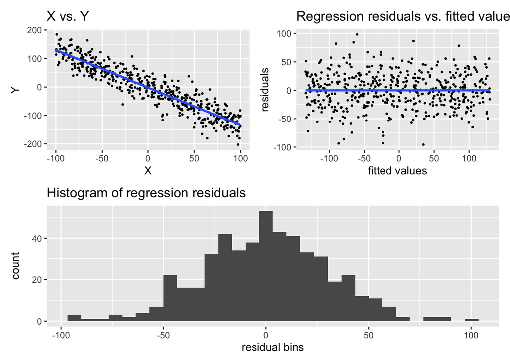

```
## beta_hat = -1.32011907668038
## 95% confindence interval for beta: [-1.36662544586935, -1.27361270749142]
## t value: -55.7706279235437
## degrees of freedom: 498
## p-value: 2.66122226028948e-216
##
## H_0 is rejected at a 5% significance level
##
## Conclusion: since the p-value is less than 0.05, at a 5% significance level, there is sufficient evidence to reject the null hypothesis in favour of the alternative and conclude that there is a linear relationship between variables X and Y
```

```r
input(not_signif)
hypothesis()
```

```
## testing H_0: beta = 0 against H_1: beta != 0
```

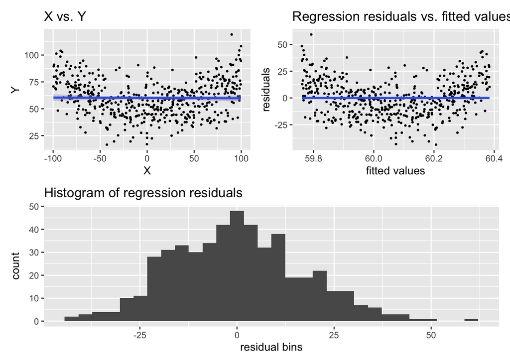

```r
assumptions()
```

```r
f <- fit()
```

```
## beta_hat = -0.00312372576706866
## 95% confindence interval for beta: [-0.0290640133318266, 0.0228165617976893]
## t value: -0.236593591005415
## degrees of freedom: 498
## p-value: 0.813069376144183
```

```r
decision(f)
```

```
## H_0 is retained at a 5% significance level
```

```r
conclusion(f)
```

```
## Conclusion: since the p-value is greater than 0.05, at a 5% significance level, the null hypothesis is retained since there is insufficient evidence to conclude that there is a linear relationship between variables X and Y
```

```r
mytest()
```

```
## testing H_0: beta = 0 against H_1: beta != 0
##
```

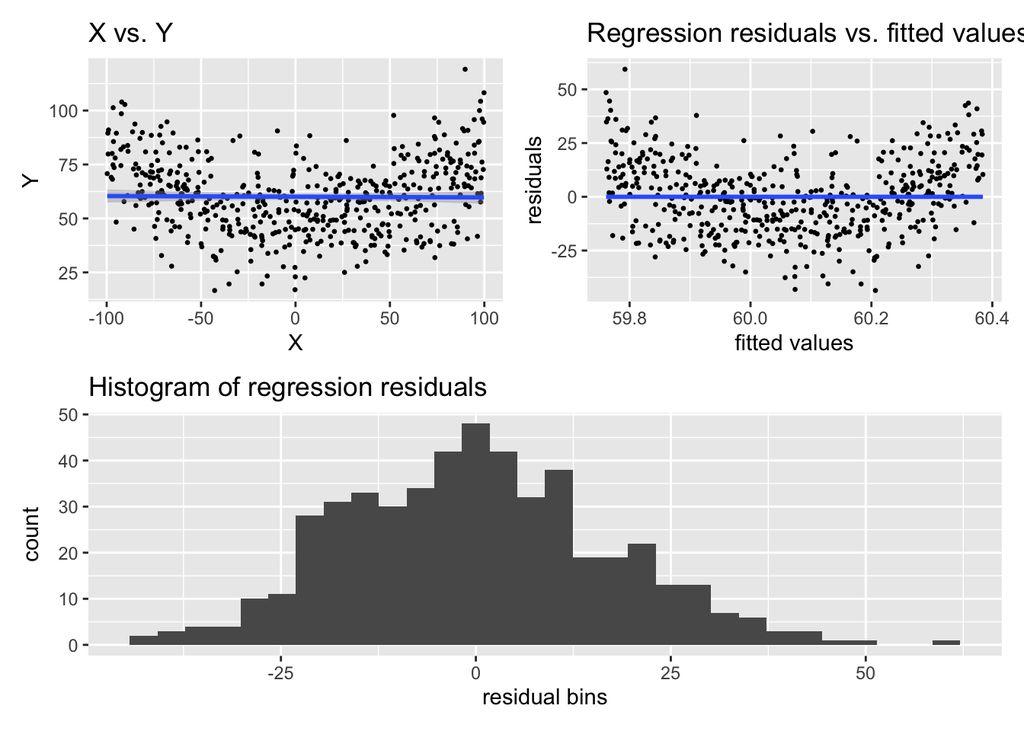

```
## beta_hat = -0.00312372576706866
## 95% confindence interval for beta: [-0.0290640133318266, 0.0228165617976893]
## t value: -0.236593591005415
## degrees of freedom: 498
## p-value: 0.813069376144183
##
## H_0 is retained at a 5% significance level
##
## Conclusion: since the p-value is greater than 0.05, at a 5% significance level, the null hypothesis is retained since there is insufficient evidence to conclude that there is a linear relationship between variables X and Y
```